# Reproducibility Standards in Economics (and beyond)

JHU FOSSProF Summative Event

Alan Lujan

alujan@jhu.edu

Johns Hopkins University AAP

Chris Carroll

ccarroll@jhu.edu

Johns Hopkins University

October 7, 2024

## REMARK Motivation

- Econ lags in reproducibility practices
- State of field: for *published* papers
  - `.zip` archive has *some files*
    - rarely works ‘out of the box’
  - Top-5 journals have a ‘data editor’
    - Very expensive
    - Excellent barrier to competition
    - Data $\neq$ results

## [Econ-ARK](https://econ-ark.org) REMARK solutions

- *Standards* for reproducibility of compute
  - self-contained and complete projects
  - executable on any modern computer
- Emphasis on:
  - minimally good code
    - enforced algorithmically
    - would be huge improvement
    - “ChatGPT, fix my documentation”
  - explicit claims (“Risk Aversion: [2.5,3.5]”)
  - standardized metadata

## So Far: [About 23+3 REMARKs](https://econ-ark.org/materials)

- Many replicating canonical papers
- Three new ones created for FossProF:
  - [Imai_Keane (2004) by John Green](https://github.com/JohnRGreen/ImaiKeane_replication)
  - [DeNardi (2004) by Ashish Kumar](https://github.com/ashishk87/DeNardi_2004_replication)
  - [Aiyagari (1994) by Adam Edwards](https://github.com/Adam-Edwards-JHU/Aiyagari1994QJE)
- Paul Romer:
  - This is the future of academic publishing

## *Jointly* Reproducible: Code and Math and Text

- Solved: most computational aspects
  - [Docker containers](https://docker.com) for universality
    - Linux, Windows, MacOS, AWS, …
  - version control (git/[GitHub](https://github.com)) = ownership
  - [cff references](https://citation-file-format.github.io/) make it findable/indexable
  - [Zenodo](https://zenodo.org): independent “release” archiving

## Math and Text *with* Code?

- [$\LaTeX$](https://www.tug.org/texlive/) is standard for text, but…
  - definitely *not lightweight*
  - no dynamically executable content
- Now: tenuous connection *between* text and code
  - “where is equation 18 implemented”?
    - in a gestalt of interactions
- Future:
  - [“this math: implemented by this code”](https://econ-ark.org/materials/bufferstocktheory)

## FOSSProF $\rightarrow$ [Curvenote](https://curvenote.com/)

Funding let us hire open source contractor - To do things we could not do

### At our direction:

- Integrated [MyST Markdown](https://mystmd.org/) into REMARK
- Filled gaps in tools to integrate text, math, and code
- Improved $\LaTeX$ $\rightarrow$ MyST engine
  - Tools required for some of our REMARKs

### [Link to FOSSProF Final Report](https://econ-ark.github.io/FOSSProF/)

## Curvenote: $\LaTeX$

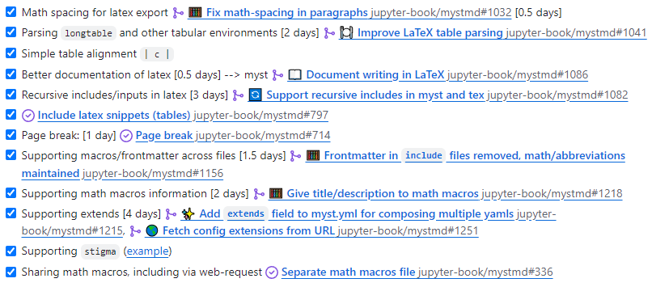

## Curvenote: Computation

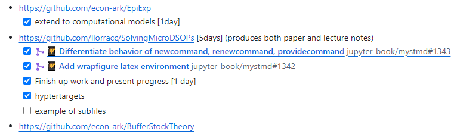

## Journal of Open Source Economics

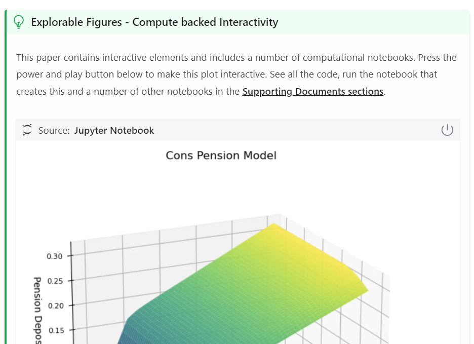

## Not Specific to Economics!

- conceived for projects using [Econ-ARK](https://docs.econ-ark.org)
  - … but doesn’t require Econ-ARK
- Not bound to economics *in any way*

## Rebranding: REMARK $\rightarrow$ SCI-PASS

- **S**cholarly **C**ommunication **I**nfrastructure for **P**ublishing and **A**rchiving **S**cientific **S**oftware
- Ambition:
  - universal standard for repr compute
    - nothing now exists (we’ve looked)
- Also short for “**sci**entific **pass**port”
  - portability/sharing of research outputs

## Long-Term Goal: ISO standard

- Adoptable by journals, libraries, archives …
- Existing software standards got started this way
  - Somebody needed it for their own purposes
- Members of our team:
  - SB: “Information Science” PhD
    - connection to archivists, librarians
  - AS: Economics PhD
    - Vetted ISO software standards for Oz